# DSCI Project 4

##Model Version 1.0

Model Version 1 refers to the original version of my loan decision model. This initial model developed for loan decision classification involved comprehensive data preprocessing, including data cleaning, type conversion, and handling of categorical variables. Class imbalance was addressed using upsampling techniques. The model was built using a Random Forest algorithm, trained on the prepared dataset, and evaluated using various metrics like accuracy, precision, recall, and F1-score. Additionally, there was an awareness of potential biases stemming from including certain demographic variables in the model, highlighting the importance of maintaining model impartiality.

```r
# Load necessary libraries
library(caret)
library(randomForest)
```

```r
library(ggplot2)
library(dplyr)
library(readxl)



data <- read.csv("Loan Data Updated.csv")


data <- data %>%
  mutate(total_loan_costs = as.numeric(total_loan_costs),
         property_value = as.numeric(property_value),
         total_points_and_fees = as.numeric(total_points_and_fees))
data$action_taken <- as.factor(data$action_taken)

set.seed(123)  # for reproducibility
split_ratio <- 0.7  # 70% for training, 30% for testing
train_indices <- sample(1:nrow(data), split_ratio * nrow(data))
train_data <- data[train_indices, ]
test_data <- data[-train_indices, ]



train_data <- upSample(train_data, y = train_data$action_taken)


# Specify the formula
formula <- action_taken ~ purchaser_type + preapproval+ loan_amount  + manufactured_home_secured_property_type + loan_type + loan_purpose + lien_status + debt_to_income_ratio + applicant_credit_score_type + co.applicant_credit_score_type + income + applicant_age + co.applicant_age + applicant_age_above_62 + co.applicant_age_above_62 + denial_reason.1  + applicant_race.1 + co.applicant_race.1 + applicant_sex + co.applicant_sex + conforming_loan_limit + derived_loan_product_type + derived_dwelling_category  # Predict 'Action Taken' using specified  variables

# Build the random forest model
model <- randomForest(formula, data = train_data, ntree = 100, na.action = na.omit)

# Print a summary of the model
print(model)
```

```
##
## Call:
##  randomForest(formula = formula, data = train_data, ntree = 100,      na.action = na.omit)
##                Type of random forest: classification
##                      Number of trees: 100
## No. of variables tried at each split: 4
##
##         OOB estimate of  error rate: 0.59%
## Confusion matrix:
##       1     3 class.error
## 1 88617   119 0.001341057
## 3   775 61650 0.012414898
```

```r
predictions <- predict(model, newdata = test_data)
confusion_matrix <- table(Actual = test_data$action_taken, Predicted = predictions)
accuracy <- sum(diag(confusion_matrix)) / sum(confusion_matrix);accuracy
```

```
## [1] 0.9952898
```

```r
precision <- confusion_matrix[2, 2] / sum(confusion_matrix[, 2]);precision
```

```
## [1] 0.9938698
```

```r
recall <- confusion_matrix[2, 2] / sum(confusion_matrix[2, ]);recall
```

```
## [1] 0.9780516
```

```r
f1_score <- 2 * (precision * recall) / (precision + recall); f1_score
```

```
## [1] 0.9858973
```

###Review Report of my work A review of the two students’ assesment of my model reveal some issues that require addressing and potential improvement of my model. These issues are raised as potential problems to address in my model due to their implications on model performance, reliability, and ethical considerations especially as it bothers on model fairness:

1. Potential Biases from Demographic Variables:
   - Problem: Including protected classes and demographic variables like ‘sex’, ‘race’, ‘ethnicity’, and ‘age’ might introduce biases that favor specific demographic groups, impacting the fairness and ethical implications of the model’s predictions.
   - Impact: Biased models can lead to discriminatory or unfair outcomes, affecting trust and reliability, especially in sensitive domains like loan decisions.
2. Handling Missing Data Using `na.omit`:
   - Problem: Using `na.omit` to handle missing data may result in the removal of rows with any missing values, potentially reducing the available information for model training.
   - Impact: Reduced dataset size may lead to information loss and affect the model’s ability to generalize well to new data, impacting predictive performance.
3. Class Imbalance Approach Using `upSample`:
   - Problem: Upsampling the minority class to handle class imbalance may introduce synthetic data that doesn’t naturally exist in the dataset, potentially influencing the model’s learning process and generalization to new data.
   - Impact: Oversampling techniques might lead to overfitting, where the model performs well on training data but poorly on unseen data, reducing its real-world applicability.

Addressing these issues is crucial to enhance the model’s performance, reliability, and ethical soundness. Exploring alternative methods for handling missing data, re-evaluating the inclusion of protective classes, and considering different strategies for handling class imbalance could potentially mitigate these concerns and improve the model’s overall effectiveness.

###Enhancements to My Model

## 1. Refined Model Building Approach (Version 2.0):

I re-evaluated the feature selection process by potentially excluding certain columns to minimize bias, particularly in protected classes like sex, race, ethnicity, and age. The goal of this step is to create a more impartial model.

#Implications: Potential Bias Mitigation: The re-evaluation of column inclusion aims to create a less biased model by potentially excluding protected classes, improving fairness in predictions.

#Rationale Behind Change: Mitigating Bias: Revisiting column selection, especially related to protected classes, aligns with the goal of creating a more impartial and fair model by potentially excluding variables that could introduce bias.

```r
# Load necessary libraries
library(caret)
library(randomForest)
library(ggplot2)
library(dplyr)
library(readxl)



data <- read.csv("Loan Data Updated.csv")


data <- data %>%
  mutate(total_loan_costs = as.numeric(total_loan_costs),
         property_value = as.numeric(property_value),
         total_points_and_fees = as.numeric(total_points_and_fees))
data$action_taken <- as.factor(data$action_taken)

set.seed(123)  # for reproducibility
split_ratio <- 0.7  # 70% for training, 30% for testing
train_indices <- sample(1:nrow(data), split_ratio * nrow(data))
train_data <- data[train_indices, ]
test_data <- data[-train_indices, ]



train_data <- upSample(train_data, y = train_data$action_taken)


# Specify the formula
formula <- action_taken ~ purchaser_type + preapproval+ loan_amount  + manufactured_home_secured_property_type + loan_type + loan_purpose + lien_status + debt_to_income_ratio + applicant_credit_score_type + co.applicant_credit_score_type + income + denial_reason.1 + conforming_loan_limit + derived_loan_product_type + derived_dwelling_category

# Predict 'Action Taken' using specified  variables

# Build the random forest model
model <- randomForest(formula, data = train_data, ntree = 100, na.action = na.omit)

# Print a summary of the model
print(model)
```

```
##
## Call:
##  randomForest(formula = formula, data = train_data, ntree = 100,      na.action = na.omit)
##                Type of random forest: classification
##                      Number of trees: 100
## No. of variables tried at each split: 3
##
##         OOB estimate of  error rate: 0.82%
## Confusion matrix:
##        1      3 class.error
## 1 186558    521  0.00278492
## 3   2483 176192  0.01389674
```

```r
predictions <- predict(model, newdata = test_data)
confusion_matrix <- table(Actual = test_data$action_taken, Predicted = predictions)
accuracy <- sum(diag(confusion_matrix)) / sum(confusion_matrix);accuracy
```

```
## [1] 0.9951909
```

```r
precision <- confusion_matrix[2, 2] / sum(confusion_matrix[, 2]);precision
```

```
## [1] 0.9917679
```

```r
recall <- confusion_matrix[2, 2] / sum(confusion_matrix[2, ]);recall
```

```
## [1] 0.9858493
```

```r
f1_score <- 2 * (precision * recall) / (precision + recall); f1_score
```

```
## [1] 0.9887997
```

## 2. Data Preprocessing Enhancement (Version 2.2):

Introduction of a more robust missing data handling technique: implemented mode imputation function (get_mode) to handle missing values across columns. This helps retain more data for analysis and modeling.

#Implications: Enhanced Data Integrity: Mode imputation preserves more data compared to na.omit, ensuring a more comprehensive dataset for analysis and modeling.

#Rationale Behind Changes: Improved Data Integrity: Mode imputation offers a more inclusive approach to handling missing data, minimizing data loss and ensuring a more comprehensive dataset.

```r
# Load necessary libraries
library(caret)
library(randomForest)
library(ggplot2)
library(dplyr)
library(readxl)

# Read data
data_path <- file.path( "Loan Data Updated.csv")
data <- read.csv(data_path)

# Data preprocessing steps
data <- data %>%
  mutate(
    total_loan_costs = as.numeric(total_loan_costs),
    property_value = as.numeric(property_value),
    total_points_and_fees = as.numeric(total_points_and_fees)
  )
# Handle missing values for non-target columns
get_mode <- function(x) {
  unique_x <- unique(x)
  unique_x[which.max(tabulate(match(x, unique_x)))]
}

cols_to_impute <- setdiff(names(data), "action_taken")  # Exclude target column
for (col in cols_to_impute) {
  mode_val <- get_mode(data[[col]])
  data[[col]][is.na(data[[col]])] <- mode_val
}

# Convert action_taken to factor
data$action_taken <- as.factor(data$action_taken)

# Split data into training and testing sets
set.seed(123)  # for reproducibility
split_ratio <- 0.7  # 70% for training, 30% for testing
train_indices <- sample(1:nrow(data), split_ratio * nrow(data))
train_data <- data[train_indices, ]
test_data <- data[-train_indices, ]

# Upsample the training data
train_data <- upSample(train_data, y = train_data$action_taken)

# Specify the formula
formula <- action_taken ~ purchaser_type + preapproval + loan_amount +
  manufactured_home_secured_property_type + loan_type + loan_purpose +
  lien_status + debt_to_income_ratio + applicant_credit_score_type +
  co.applicant_credit_score_type + income + denial_reason.1 +
  conforming_loan_limit + derived_loan_product_type + derived_dwelling_category

# Build the random forest model
model <- randomForest(formula, data = train_data, ntree = 100, na.action = na.omit)

# Print a summary of the model
print(model)
```

```
##
## Call:
##  randomForest(formula = formula, data = train_data, ntree = 100,      na.action = na.omit)
##                Type of random forest: classification
##                      Number of trees: 100
## No. of variables tried at each split: 3
##
##         OOB estimate of  error rate: 0.77%
## Confusion matrix:
##        1      3 class.error
## 1 189425    646  0.00339873
## 3   2277 187463  0.01200063
```

```r
predictions <- predict(model, newdata = test_data)
confusion_matrix <- table(Actual = test_data$action_taken, Predicted = predictions)
accuracy <- sum(diag(confusion_matrix)) / sum(confusion_matrix);accuracy
```

```
## [1] 0.9948093
```

```r
precision <- confusion_matrix[2, 2] / sum(confusion_matrix[, 2]);precision
```

```
## [1] 0.9892708
```

```r
recall <- confusion_matrix[2, 2] / sum(confusion_matrix[2, ]);recall
```

```
## [1] 0.9873715
```

```r
f1_score <- 2 * (precision * recall) / (precision + recall); f1_score
```

```
## [1] 0.9883202
```

## 3. Improved Handling of Class Imbalance (Version 2.3):

In this version of the model, I decided to change class imbalance appraoch based on peer review, from upsampling (used in earlier versions of the model) to downsampling using downSample to address class imbalance. Downsampling involves reducing the number of instances in the majority class to balance the dataset, potentially mitigating overfitting issues associated with upsampling.

#Implications: Balanced Dataset: Downsampling addresses class imbalance, potentially reducing the risk of overfitting and enabling the model to learn more effectively from both classes.

#Rationale Behind Changes: Addressing Class Imbalance: Switching to downsampling aims to create a more balanced dataset, potentially improving the model’s generalization to unseen data and reducing the impact of class imbalance.

```r
# Load necessary libraries
library(caret)
library(randomForest)
library(ggplot2)
library(dplyr)
library(readxl)

# Read data
data <- read.csv("Loan Data Updated.csv")

# Data preprocessing steps
data <- data %>%
  mutate(
    total_loan_costs = as.numeric(total_loan_costs),
    property_value = as.numeric(property_value),
    total_points_and_fees = as.numeric(total_points_and_fees)
  )
# Handle missing values for non-target columns
get_mode <- function(x) {
  unique_x <- unique(x)
  unique_x[which.max(tabulate(match(x, unique_x)))]
}

cols_to_impute <- setdiff(names(data), "action_taken")  # Exclude target column
for (col in cols_to_impute) {
  mode_val <- get_mode(data[[col]])
  data[[col]][is.na(data[[col]])] <- mode_val
}

# Convert action_taken to factor
data$action_taken <- as.factor(data$action_taken)

# Split data into training and testing sets
set.seed(123)  # for reproducibility
split_ratio <- 0.7  # 70% for training, 30% for testing
train_indices <- sample(1:nrow(data), split_ratio * nrow(data))
train_data <- data[train_indices, ]
test_data <- data[-train_indices, ]

# Downsampling the training data
train_data <- downSample(train_data, y = train_data$action_taken)

# Specify the formula
formula <- action_taken ~ purchaser_type + preapproval + loan_amount +
  manufactured_home_secured_property_type + loan_type + loan_purpose +
  lien_status + debt_to_income_ratio + applicant_credit_score_type +
  co.applicant_credit_score_type + income + denial_reason.1+
  conforming_loan_limit + derived_loan_product_type + derived_dwelling_category

# Build the random forest model
model <- randomForest(formula, data = train_data, ntree = 100, na.action = na.omit)

# Print a summary of the model
print(model)
```

```
##
## Call:
##  randomForest(formula = formula, data = train_data, ntree = 100,      na.action = na.omit)
##                Type of random forest: classification
##                      Number of trees: 100
## No. of variables tried at each split: 3
##
##         OOB estimate of  error rate: 0.82%
## Confusion matrix:
##       1     3 class.error
## 1 55751   144 0.002576259
## 3   768 55034 0.013762948
```

```r
predictions <- predict(model, newdata = test_data)
confusion_matrix <- table(Actual = test_data$action_taken, Predicted = predictions)
accuracy <- sum(diag(confusion_matrix)) / sum(confusion_matrix);accuracy
```

```
## [1] 0.9951224
```

```r
precision <- confusion_matrix[2, 2] / sum(confusion_matrix[, 2]);precision
```

```
## [1] 0.9914255
```

```r
recall <- confusion_matrix[2, 2] / sum(confusion_matrix[2, ]);recall
```

```
## [1] 0.9866035
```

```r
f1_score <- 2 * (precision * recall) / (precision + recall); f1_score
```

```
## [1] 0.9890086
```

##Other improvements made to the model: After presenting the my model enhancements to the class, I got some valuable feedbacks that informed further improvement to my mode. These include:

##Explore using relative path for code portability: Relative paths offer three key benefits:

1. Portability: They detach code from specific directory structures, enhancing its adaptability across systems. This flexibility allows easy movement and sharing without requiring updates to absolute paths.
2. Development Efficiency: By using relative paths, developers can seamlessly work in diverse environments without the need to modify absolute paths. This adaptability fosters smoother collaboration and efficient code sharing.
3. Maintainability: Relative paths reduce the risk of broken references when directory structures change. This strengthens codebases, making them more resilient to structural modifications and ensuring their longevity.

##Removal of denial_reason.1 from the preditors Denial Reason 1 has a high correlation to the outcome variable action_taken. Hence including it as a variable used to predict action_taken is not ideal. Hence the need to remove it.

The rationale for removing Denial Reason 1 as a predictor for predicting the outcome variable “action_taken” lies in its high correlation with the said outcome. This high correlation poses challenges when utilizing it as a predictive variable:

1. Correlation Impact: Since it has a high correlation with the outcome variable (“action_taken”), it can distort the predictive model’s efficacy. Such a strong relationship might lead to issues like multicollinearity, making it difficult to isolate the independent effect of other predictors on the outcome.
2. Model Interpretability: Including a highly correlated variable like Denial Reason 1 could hinder the interpretability of the model. It might overshadow the impact of other predictors, making it challenging to discern their individual contributions to predicting “action_taken.”
3. Redundancy: Since Denial Reason 1 is closely linked to the outcome variable, its inclusion might not add significant additional information to the model. Removing it could streamline the model without sacrificing predictive accuracy.
4. Model Overfitting: In some cases, like the one at hand, a highly correlated predictor might lead to overfitting, where the model performs exceptionally well on the training data but fails to generalize to new, unseen data. Removing such variables can help mitigate overfitting issues.

Therefore, the decision to remove Denial Reason 1 as a predictor is based on the desire to enhance the model’s interpretability, mitigate multicollinearity, prevent overfitting, and ensure that other relevant predictors can exert their independent influence on predicting “action_taken.”

```r
# Load necessary libraries
library(caret)
library(randomForest)
library(ggplot2)
library(dplyr)
library(readxl)

# Read data
data_path <- file.path( "Loan Data Updated.csv")
data <- read.csv(data_path)

# Data preprocessing steps
data <- data %>%
  mutate(
    total_loan_costs = as.numeric(total_loan_costs),
    property_value = as.numeric(property_value),
    total_points_and_fees = as.numeric(total_points_and_fees)
  )
# Handle missing values for non-target columns
get_mode <- function(x) {
  unique_x <- unique(x)
  unique_x[which.max(tabulate(match(x, unique_x)))]
}

cols_to_impute <- setdiff(names(data), "action_taken")  # Exclude target column
for (col in cols_to_impute) {
  mode_val <- get_mode(data[[col]])
  data[[col]][is.na(data[[col]])] <- mode_val
}

# Convert action_taken to factor
data$action_taken <- as.factor(data$action_taken)

# Split data into training and testing sets
set.seed(123)  # for reproducibility
split_ratio <- 0.7  # 70% for training, 30% for testing
train_indices <- sample(1:nrow(data), split_ratio * nrow(data))
train_data <- data[train_indices, ]
test_data <- data[-train_indices, ]

# Downsampling the training data
train_data <- downSample(train_data, y = train_data$action_taken)

# Specify the formula
formula <- action_taken ~ purchaser_type + preapproval + loan_amount +
  manufactured_home_secured_property_type + loan_type + loan_purpose +
  lien_status + debt_to_income_ratio + applicant_credit_score_type +
  co.applicant_credit_score_type + income +
  conforming_loan_limit + derived_loan_product_type + derived_dwelling_category

# Build the random forest model
model <- randomForest(formula, data = train_data, ntree = 100, na.action = na.omit)

# Print a summary of the model
print(model)
```

```
##
## Call:
##  randomForest(formula = formula, data = train_data, ntree = 100,      na.action = na.omit)
##                Type of random forest: classification
##                      Number of trees: 100
## No. of variables tried at each split: 3
##
##         OOB estimate of  error rate: 19.7%
## Confusion matrix:
##       1     3 class.error
## 1 40177 15718   0.2812058
## 3  6284 49518   0.1126125
```

```r
predictions <- predict(model, newdata = test_data)
confusion_matrix <- table(Actual = test_data$action_taken, Predicted = predictions)
accuracy <- sum(diag(confusion_matrix)) / sum(confusion_matrix);accuracy
```

```
## [1] 0.7571551
```

```r
precision <- confusion_matrix[2, 2] / sum(confusion_matrix[, 2]);precision
```

```
## [1] 0.4754506
```

```r
recall <- confusion_matrix[2, 2] / sum(confusion_matrix[2, ]);recall
```

```
## [1] 0.8890738
```

```r
f1_score <- 2 * (precision * recall) / (precision + recall); f1_score
```

```
## [1] 0.6195722
```

##Further Discoveries and Improvement attempts

I discovered that removing the denial_reason 1 variable impacted on the model’s performance across all metrics.

The result reveals weaknesses including a high error rate at 19.7%, notable imbalanced class errors between Class 1 (28.1%) and Class 3 (11.3%), and lower sensitivity and specificity for both classes. These findings suggest potential difficulties in accurately classifying instances, likely influenced by class imbalances and the risk of overfitting, leading to unreliable predictions. These weaknesses could hinder the model’s ability to generalize well to new data and might impact decision-making if relied upon without acknowledging these limitations. Addressing these issues would involve revisiting model architecture, handling class imbalances, and exploring alternative approaches to bolster predictive accuracy and reliability.

To mitigate this, I decided to extract the feature importance of my model and see the most important features and further explore how to leverage the information to improve my model’s performance.

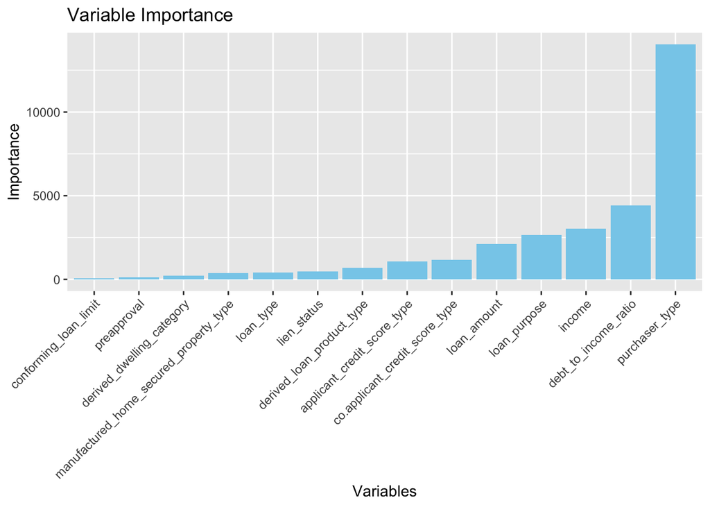

```r
# Fit a random forest model
model <- randomForest(formula, data = train_data, ntree = 100, na.action = na.omit)

# Extract feature importance
importance <- importance(model)
var_importance <- data.frame(
  Variables = row.names(importance),
  Importance = round(importance[, 1], 2)  # Use 'MeanDecreaseGini' or another relevant metric
)

# Sort variables by importance
var_importance <- var_importance[order(-var_importance$Importance), ]

# Visualize feature importance
library(ggplot2)
ggplot(var_importance, aes(x = reorder(Variables, Importance), y = Importance)) +
  geom_bar(stat = "identity", fill = "skyblue") +
  labs(x = "Variables", y = "Importance") +
  theme(axis.text.x = element_text(angle = 45, hjust = 1)) +
  ggtitle("Variable Importance")
```

Purchaser_type, Debt_to_Income_Ratio and income are top on the chart of important feartures in my model, so I will explore feature enginering leveraging this information.

```r
# Feature engineering

# Convert 'debt_to_income_ratio' to numeric
train_data$debt_to_income_ratio <- as.numeric(as.character(train_data$debt_to_income_ratio))
test_data$debt_to_income_ratio <- as.numeric(as.character(test_data$debt_to_income_ratio))
# Check if conversion is successful
str(train_data$debt_to_income_ratio)
```

```
##  num [1:115706] 48 46 40 40 NA NA NA 46 43 NA ...
```

```r
str(test_data$debt_to_income_ratio)
```

```
##  num [1:109117] 39 NA 37 NA 40 48 NA NA NA 38 ...
```

```r
# Debt-to-Income Ratio Category
train_data$dti_category <- cut(train_data$debt_to_income_ratio,
                               breaks = c(-Inf, 20, 30, Inf),
                               labels = c("Low", "Medium", "High"),
                               right = FALSE)

test_data$dti_category <- cut(test_data$debt_to_income_ratio,
                              breaks = c(-Inf, 20, 30, Inf),
                              labels = c("Low", "Medium", "High"),
                              right = FALSE)

# Income Category
train_data$income_category <- cut(train_data$income,
                                  breaks = c(-Inf, 50000, 100000, Inf),
                                  labels = c("Low", "Medium", "High"),
                                  right = FALSE)

test_data$income_category <- cut(test_data$income,
                                 breaks = c(-Inf, 50000, 100000, Inf),
                                 labels = c("Low", "Medium", "High"),
                                 right = FALSE)

# Update the formula with new features
new_formula <- update(formula, . ~ . + dti_category + income_category)

# Remove rows with any NA values
data <- na.omit(data)


# Retrain the model with the updated formula
updated_model <- randomForest(new_formula, data = train_data, ntree = 100, na.action = na.omit)

# Predictions using the updated model
updated_predictions <- predict(updated_model, newdata = test_data)
updated_confusion_matrix <- table(Actual = test_data$action_taken, Predicted = updated_predictions)

# Calculate performance metrics
updated_accuracy <- sum(diag(updated_confusion_matrix)) / sum(updated_confusion_matrix)
updated_precision <- updated_confusion_matrix[2, 2] / sum(updated_confusion_matrix[, 2])
updated_recall <- updated_confusion_matrix[2, 2] / sum(updated_confusion_matrix[2, ])
updated_f1_score <- 2 * (updated_precision * updated_recall) / (updated_precision + updated_recall)

# Check the updated performance metrics
updated_accuracy
```

```
## [1] 0.7663337
```

```r
updated_precision
```

```
## [1] 0.385905
```

```r
updated_recall
```

```
## [1] 0.8548143
```

```r
updated_f1_score
```

```
## [1] 0.5317514
```

##Deploying AUC to assess my classification model’s performance: I decided to deploy a model assessment metric that will specifically help me identify my classification model’s ability to differentiate between classes—specifically, positive and negative ones—on a scale from 0 to 1. I decided to use the Area Under the Curve (AUC).

An AUC of 1 signifies a flawless classifier that perfectly segregates positive and negative instances, while an AUC of 0.5 indicates chance-level performance with no discrimination ability. Values between 0.5 and 1 denote varying degrees of discriminatory power.

```r
# Load necessary libraries
library(caret)
library(randomForest)
library(ggplot2)
library(dplyr)
library(readxl)

# Read data
data_path <- file.path( "Loan Data Updated.csv")
data <- read.csv(data_path)

# Data preprocessing steps
data <- data %>%
  mutate(
    total_loan_costs = as.numeric(total_loan_costs),
    property_value = as.numeric(property_value),
    total_points_and_fees = as.numeric(total_points_and_fees)
  )
# Handle missing values for non-target columns
get_mode <- function(x) {
  unique_x <- unique(x)
  unique_x[which.max(tabulate(match(x, unique_x)))]
}

cols_to_impute <- setdiff(names(data), "action_taken")  # Exclude target column
for (col in cols_to_impute) {
  mode_val <- get_mode(data[[col]])
  data[[col]][is.na(data[[col]])] <- mode_val
}

# Convert action_taken to factor
data$action_taken <- as.factor(data$action_taken)

# Split data into training and testing sets
set.seed(123)  # for reproducibility
split_ratio <- 0.7  # 70% for training, 30% for testing
train_indices <- sample(1:nrow(data), split_ratio * nrow(data))
train_data <- data[train_indices, ]
test_data <- data[-train_indices, ]

# Downsampling the training data
train_data <- downSample(train_data, y = train_data$action_taken)

# Specify the formula
formula <- action_taken ~ purchaser_type + preapproval + loan_amount +
  manufactured_home_secured_property_type + loan_type + loan_purpose +
  lien_status + debt_to_income_ratio + applicant_credit_score_type +
  co.applicant_credit_score_type + income +
  conforming_loan_limit + derived_loan_product_type + derived_dwelling_category

# Build the random forest model
model <- randomForest(formula, data = train_data, ntree = 100, na.action = na.omit)

# Print a summary of the model
print(model)
```

```
##
## Call:
##  randomForest(formula = formula, data = train_data, ntree = 100,      na.action = na.omit)
##                Type of random forest: classification
##                      Number of trees: 100
## No. of variables tried at each split: 3
##
##         OOB estimate of  error rate: 19.7%
## Confusion matrix:
##       1     3 class.error
## 1 40177 15718   0.2812058
## 3  6284 49518   0.1126125
```

```r
predictions <- predict(model, newdata = test_data)
confusion_matrix <- table(Actual = test_data$action_taken, Predicted = predictions)
accuracy <- sum(diag(confusion_matrix)) / sum(confusion_matrix);accuracy
```

```
## [1] 0.7571551
```

```r
precision <- confusion_matrix[2, 2] / sum(confusion_matrix[, 2]);precision
```

```
## [1] 0.4754506
```

```r
recall <- confusion_matrix[2, 2] / sum(confusion_matrix[2, ]);recall
```

```
## [1] 0.8890738
```

```r
f1_score <- 2 * (precision * recall) / (precision + recall); f1_score
```

```
## [1] 0.6195722
```

```r
# Calculate AUC-ROC
library(pROC)
roc_values <- roc(test_data$action_taken, as.numeric(predictions))
auc_score <- auc(roc_values)
auc_score
```

```
## Area under the curve: 0.8042
```

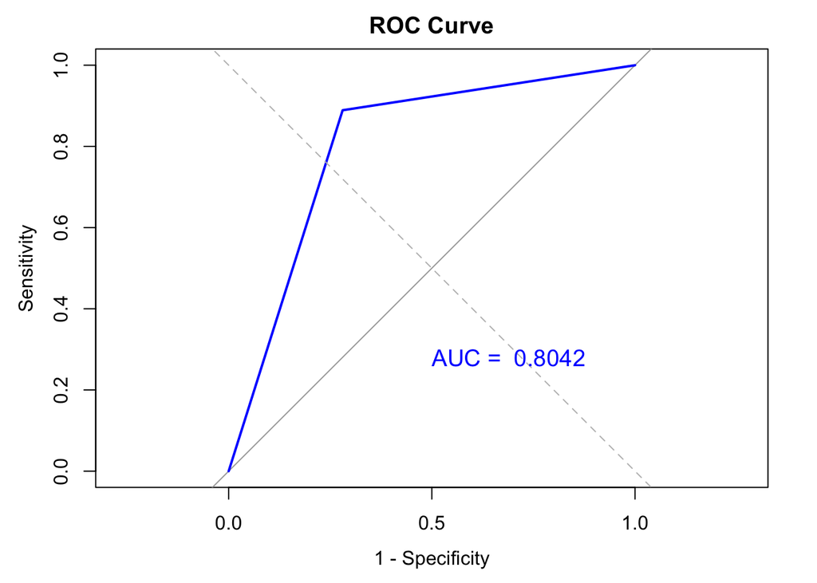

```r
# Plot AUC-ROC curve
plot(roc_values, main = "ROC Curve", col = "blue", legacy.axes = TRUE)
abline(a = 0, b = 1, lty = 2, col = "grey")  # Add a diagonal reference line

# Display AUC value on the plot
text(0.5, 0.3, paste("AUC = ", round(auc_score, 4)), adj = c(0, 1), col = "blue", cex = 1.2)
```